# Differential Methylation Analysis of Esophageal Squamous Cell Carcinoma (ESCC) and Paired Normal Tissue Samples

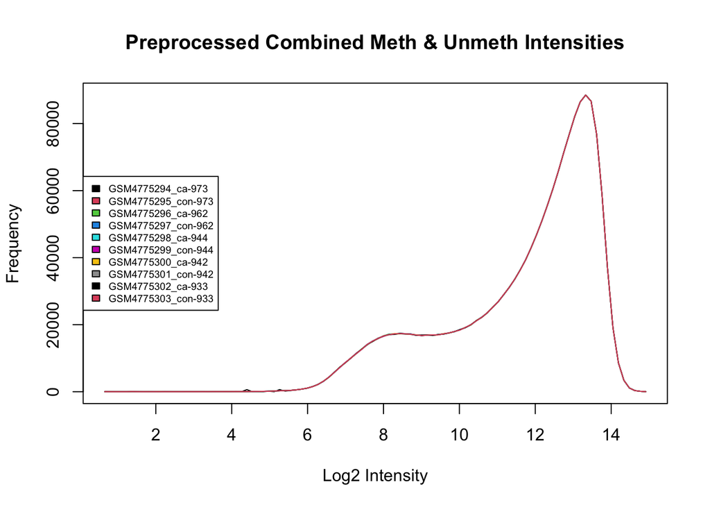

```r
# Plot combined meth and unmeth intensities
multifreqpoly(
  mat = log2(rbind(getMeth(fibromethyl_N) + 1, getUnmeth(fibromethyl_N)
  ) + 1),
  main = "Preprocessed Combined Meth & Unmeth Intensities",
  xlab = "Log2 Intensity",
  legend = list(
    x = "left",
    legend = colnames(fibromethyl_N),
    fill = 1:ncol(fibromethyl_N),
    cex = 0.6
  )
)
```

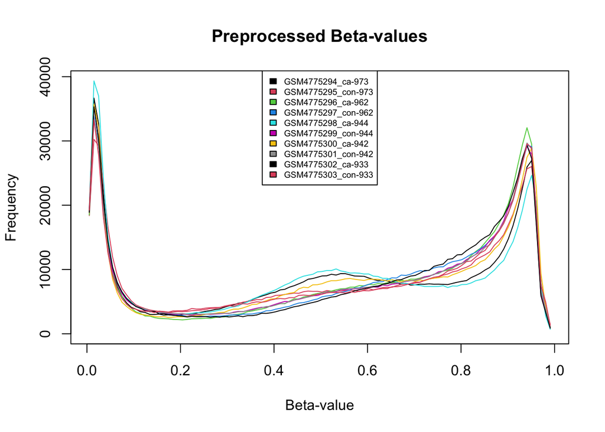

```r
# Plot beta-values
multifreqpoly(
  mat = getB(fibromethyl_N),
  main = "Preprocessed Beta-values",
  xlab = "Beta-value",
  legend = list(
    x = "top",
    legend = colnames(fibromethyl_N),
    fill = 1:ncol(fibromethyl_N),
    cex = 0.6
  )
)
```

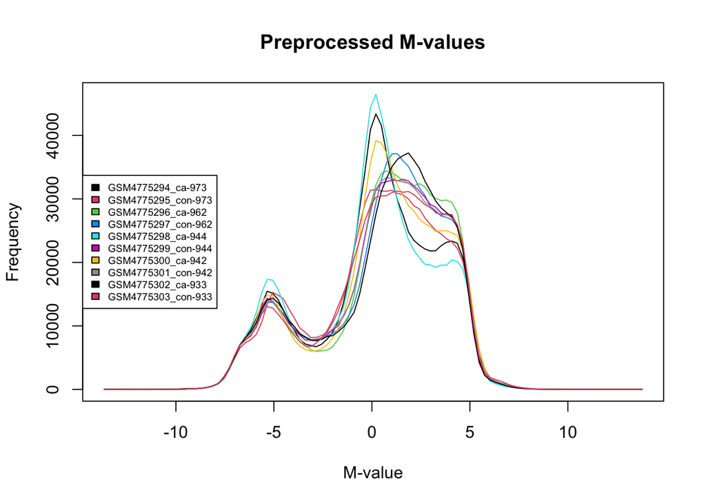

```r
# Plot M-values
multifreqpoly(
  mat = getM(fibromethyl_N),
  main = "Preprocessed M-values",
  xlab = "M-value",
  legend = list(
    x = "left",
    legend = colnames(fibromethyl_N),
    fill = 1:ncol(fibromethyl_N),
    cex = 0.6
  )
)
```

## 6. Differetial Methylaton analysis

### 6.1. Define the experimental design

- The block variable is set to the PatientID column, which groups samples by patient. This blocking factor accounts for the paired structure of the data, where each patient may contribute samples for both tissue types. By using table, the balance of samples between tissue types for each patient is checked.
- Design matrix is created with model.matrix to specify the relationship between the response variable (e.g., methylation) and the predictor (TissueType). This matrix includes dummy variables for tissue types, allowing the model to evaluate the effects of “ESCC” compared to “NORMAL”.

```r
# 1. Get col_data information (patient data and tissue type)
col_data <- pData(fibromethyl_N)

# 2. Extract the tissue type information from the sample metadata and define it as a factor with levels "ESCC" (tumor) and "NORMAL" (healthy tissue)
col_data$TissueType <- factor(col_data$TissueType, levels = c("NORMAL", "ESCC"))

# 3. Use sub() function to remove the "ca-" and "con-" prefixes from PatientID
col_data$PatientID <- sub("^ca-|^con-", "", col_data$PatientID)

# 4. Set up the 'block' for adjusting patient-specific effects in the model
# Here, PatientID is used as the blocking factor to control for patient-specific effects (e.g., each patient could have samples from both tissue types)
block <- col_data$PatientID
table(col_data$PatientID, col_data$TissueType)  # Check how many samples per patient and tissue type
```

```
##
##       NORMAL ESCC
##   933      1    1
##   942      1    1
##   944      1    1
##   962      1    1
##   973      1    1
```

```r
# 5. Create the design matrix based on TissueType
# The model matrix is created to specify the design of the study, where the outcome variable is modeled as a function of tissue type
design <- model.matrix(~ TissueType, data = col_data)

# 6. Check the design matrix to verify its structure
# The design matrix should show how each tissue type is coded (e.g., dummy variable for "ESCC" versus "NORMAL")
print(design)
```

```
##                    (Intercept) TissueTypeESCC
## GSM4775294_ca-973            1              1
## GSM4775295_con-973           1              0
## GSM4775296_ca-962            1              1
## GSM4775297_con-962           1              0
## GSM4775298_ca-944            1              1
## GSM4775299_con-944           1              0
## GSM4775300_ca-942            1              1
## GSM4775301_con-942           1              0
## GSM4775302_ca-933            1              1
## GSM4775303_con-933           1              0
## attr(,"assign")
## [1] 0 1
## attr(,"contrasts")
## attr(,"contrasts")$TissueType
## [1] "contr.treatment"
```

### 6.2. Estimate the correlation between samples from the same patient (patient-level correlation)

- Estimated correlation is around 0.06. It suggests a weak correlation between samples from the same patient. Weak correlation (0.06) implies that most of the variability in the methylation data is likely due to differences in tissue type (“NORMAL” vs “ESCC”) or other factors, rather than being heavily influenced by patient-specific characteristics.

```r
# This is important when analyzing data from multiple samples per patient
#block = patient=specific block factor, getM  provides methylation data matrix
cor_fit <- duplicateCorrelation(getM(fibromethyl_N), design, block = block)

# A result around 0.06 suggests weak correlation, indicating that the samples from the same patient do not exhibit strong similarity.
print(cor_fit$consensus.correlation)
```

```
## [1] 0.06511738
```

### 6.3. Fit a linear model to methylation M-values

-Fit a linear model to the methylation M-values using the lmFit function from the limma package. The design matrix specifies the comparison of interest (tissue type), the block accounts for patient-specific effects, and the correlation parameter incorporates the estimated correlation between paired samples from the same patient. This ensures that tissue-type differences are modeled while controlling for residual dependencies within patients.

```r
# Step 2: Fit a linear model to methylation M-values
fit <- lmFit(getM(fibromethyl_N), design, block = block, correlation = cor_fit$consensus.correlation)
```

### 6.4. Define contrasts for differential methylation

-A contrast matrix is created using makeContrasts to specify the comparison of interest—in this case, “ESCC vs NORMAL.” This step sets up the framework for testing differential methylation between the two tissue types.

```r
# Create a contrast matrix to compare ESCC vs NORMAL
contrast_matrix <- makeContrasts(ESCC_vs_NORMAL = TissueTypeESCC, levels = design)
```

Empirical Bayes smoothing with eBayes is then performed to stabilize the variance estimates, improving statistical power and reliability in detecting differential methylation signals.

```r
# Apply contrasts to the model using the contrast matrix and store in 'fit2'.
fit2 <- contrasts.fit(fit, contrast_matrix)

#Perform empirical Bayes smoothing to improve statistical power
fit2 <- eBayes(fit2)
```

### 6.5. Extract differentially methylated CpG sites

-The topTable function generates a table of differentially methylated CpG probes, sorted by significance. Adjusted p-values are calculated using the Benjamini-Hochberg (BH) method to control the false discovery rate (FDR). The resulting table provides information on the most significant CpG sites, including fold changes, p-values, and adjusted p-values.

```r
# Generate a table of differentially methylated probes
# Adjust p-values using the Benjamini-Hochberg method (FDR control)
# Form result table
LIMMAout <- topTable(fit2, adjust = "BH", number = Inf)

# print result
head(LIMMAout)
```

```
##               logFC  AveExpr        t      P.Value    adj.P.Val        B
## cg23500559 5.231598 4.168630 25.35673 2.393338e-11 1.919478e-05 13.20075
## cg06770731 4.743592 3.199862 22.97741 7.176152e-11 1.919478e-05 12.68568
## cg22811668 5.368269 3.128400 22.63223 8.491750e-11 1.919478e-05 12.60171
## cg06492111 4.953505 3.924389 21.82208 1.273125e-10 1.919478e-05 12.39419
## cg01082422 4.741744 4.025537 21.80189 1.286276e-10 1.919478e-05 12.38882
## cg04808027 5.154883 3.576289 21.72451 1.338054e-10 1.919478e-05 12.36817
```

### 6.6. Count the number of genes with adjusted p-value < 0.05

-Out of all tested CpG sites, 35,994 (about 4.18%) are significantly differentially methylated at an adjusted p-value threshold of 0.05.

```r
sum(LIMMAout$adj.P.Val < 0.05)
```

```
## [1] 35994
```

```r
sum(LIMMAout$adj.P.Val<0.05)/length(LIMMAout$adj.P.Val)
```

```
## [1] 0.04181857
```

### 6.7. Volcano plot

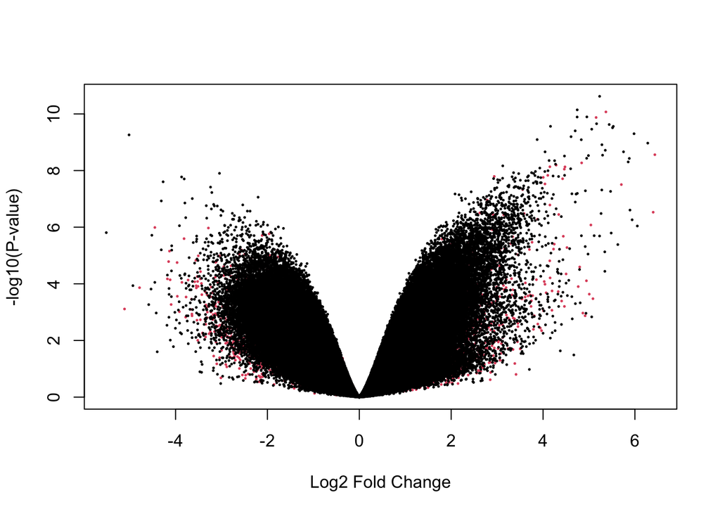

```r
volcanoplot(fit2, style="p-value", col=as.factor(LIMMAout$adj.P.Val < 0.05))
```

### 6.8. MA plot

-The majority of points cluster around a log fold change of 0, indicating no substantial differences in methylation for many CpG sites. The colored points (red) represent CpG sites with significant differential methylation, as determined by their adjusted p-value. These are spread across both positive and negative logFC values, indicating both hypermethylation and hypomethylation in “ESCC” compared to “NORMAL.

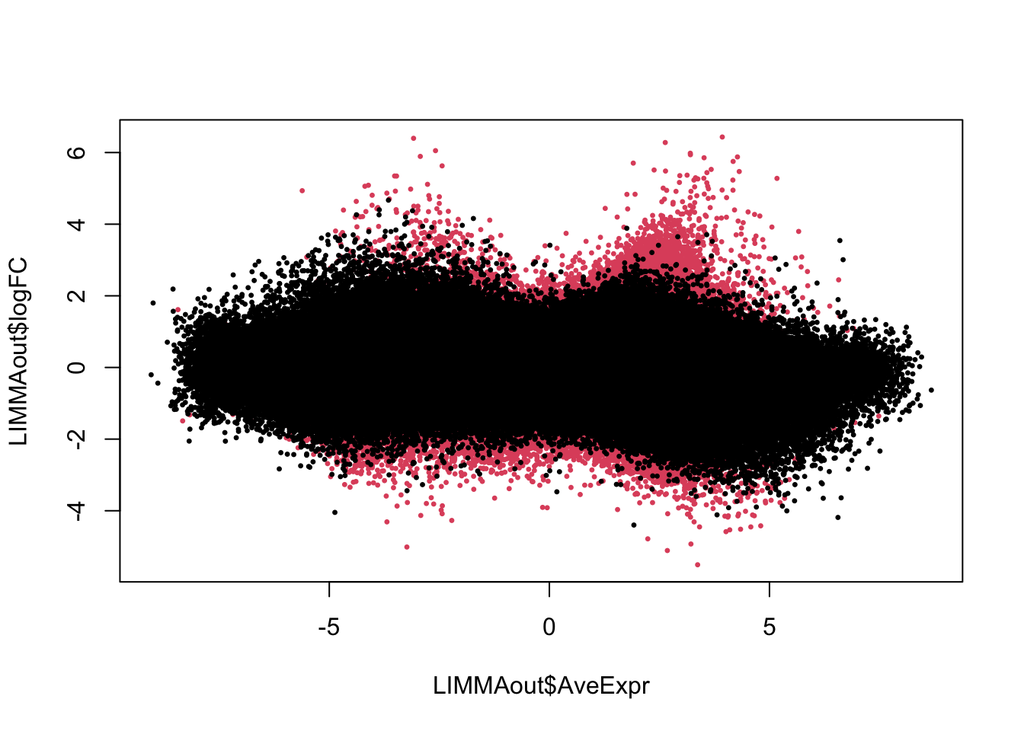

```r
plot(LIMMAout$AveExpr, LIMMAout$logFC, col=as.factor(LIMMAout$adj.P.Val<0.05), pch=20, cex=0.5)
```

### 6.9. p-value histogram

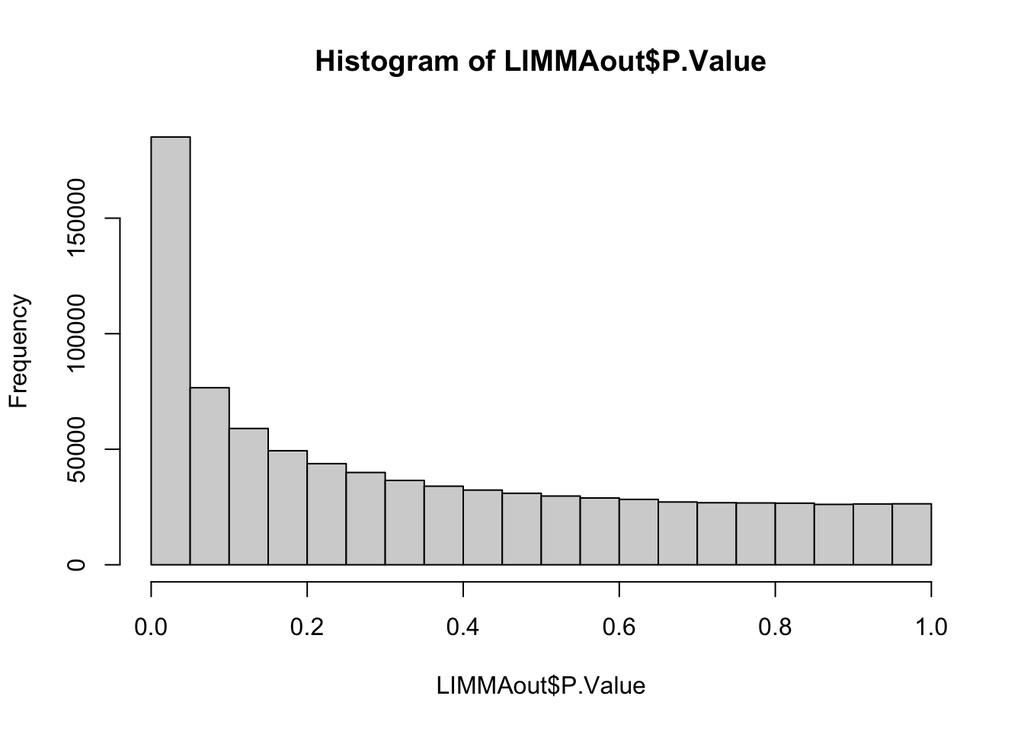

```r
hist(x = LIMMAout$P.Value)
```

## 7. Check Methylation for top results

### 7.1. Check M-values for top results

```r
#Check M-values for top results
getM(fibromethyl_N)[rownames(head(LIMMAout)), ]
```

```
##            GSM4775294_ca-973 GSM4775295_con-973 GSM4775296_ca-962
## cg23500559          7.042695          1.2607643          6.829152
## cg06770731          5.539882          0.8153324          5.781019
## cg22811668          5.948366          0.1074965          5.715503
## cg06492111          6.019603          1.2807072          6.479344
## cg01082422          6.396022          1.8120104          6.579354
## cg04808027          6.766562          0.9467753          6.075986
##            GSM4775297_con-962 GSM4775298_ca-944 GSM4775299_con-944
## cg23500559           2.006711          6.720035          1.3034339
## cg06770731           1.386503          5.269010          0.6053885
## cg22811668           1.059007          5.558811          0.4097697
## cg06492111           2.023288          6.497081          1.2022266
## cg01082422           1.584071          6.170070          1.8697109
## cg04808027           1.540002          5.976971          0.9094709
##            GSM4775300_ca-942 GSM4775301_con-942 GSM4775302_ca-933
## cg23500559          6.812625          1.4718434          6.517637
## cg06770731          5.660398          0.6044385          5.607982
## cg22811668          6.310795          0.3652889          5.529195
## cg06492111          6.691989          1.1144202          6.317692
## cg01082422          6.840083          1.7733337          5.996518
## cg04808027          5.750769          0.8070853          6.198364
##            GSM4775303_con-933
## cg23500559          1.7214003
## cg06770731          0.7286678
## cg22811668          0.2797632
## cg06492111          1.6175409
## cg01082422          1.2342000
## cg04808027          0.7909058
```

```r
# Check beta-values for top results
getB(fibromethyl_N)[rownames(head(LIMMAout)), ]
```

```
##            GSM4775294_ca-973 GSM4775295_con-973 GSM4775296_ca-962
## cg23500559         0.9881152          0.7032138         0.9868919
## cg06770731         0.9743836          0.6353753         0.9772876
## cg22811668         0.9786155          0.5169109         0.9763719
## cg06492111         0.9789182          0.7048864         0.9827594
## cg01082422         0.9796719          0.7733197         0.9812806
## cg04808027         0.9862625          0.6558413         0.9803935
##            GSM4775297_con-962 GSM4775298_ca-944 GSM4775299_con-944
## cg23500559          0.7977593         0.9864938          0.7091791
## cg06770731          0.7204559         0.9699283          0.6011142
## cg22811668          0.6730617         0.9741997          0.5685523
## cg06492111          0.7981340         0.9833155          0.6937993
## cg01082422          0.7451105         0.9783843          0.7797380
## cg04808027          0.7411806         0.9791933          0.6501532
##            GSM4775300_ca-942 GSM4775301_con-942 GSM4775302_ca-933
## cg23500559         0.9867557          0.7324584         0.9849898
## cg06770731         0.9758034          0.6009955         0.9753112
## cg22811668         0.9823566          0.5610731         0.9741889
## cg06492111         0.9846396          0.6807849         0.9815741
## cg01082422         0.9837269          0.7678668         0.9765842
## cg04808027         0.9769617          0.6339980         0.9816623
##            GSM4775303_con-933
## cg23500559          0.7647443
## cg06770731          0.6212733
## cg22811668          0.5464472
## cg06492111          0.7502327
## cg01082422          0.6969803
## cg04808027          0.6314376
```

```r
# Add the mean betas of the CAF and NAF group, and their absolute difference
LIMMAout$normalBeta <- rowMeans(getB(fibromethyl_N)[rownames(LIMMAout), pData(fibromethyl_N)$TissueType == "NORMAL"])
LIMMAout$tumorBeta <- rowMeans(getB(fibromethyl_N)[rownames(LIMMAout), pData(fibromethyl_N)$TissueType == "ESCC"])

deltaBeta <- getB(fibromethyl_N)[, pData(fibromethyl_N)$TissueType == "ESCC"] - getB(fibromethyl_N)[, pData(fibromethyl_N)$TissueType == "NORMAL"]

# Calculate the mean absolute value of differences between patients by CpG site
LIMMAout$deltaBeta <- rowMeans(abs(deltaBeta))
```

### 7.2. Annotation

```r
# Extract annotation data from the preprocessed methylation object
anno <- getAnnotation(fibromethyl_N)

# Sort in the same order as limma output, remove filtered CpGs, add missing CpGs
anno <- anno[rownames(LIMMAout),]

# Update row names of the annotation data to match the LIMMA output
rownames(anno) <- rownames(LIMMAout)
# note that if any CpGs were present in the limma output but not in the annotation ,
# these have now been added as NA rows
# any CpGs that were present in the annotation but not in LIMMAout have been removed
```

```r
colnames(anno)
```

```
##  [1] "chr"
##  [2] "pos"
##  [3] "strand"
##  [4] "Name"
##  [5] "AddressA"
##  [6] "AddressB"
##  [7] "ProbeSeqA"
##  [8] "ProbeSeqB"
##  [9] "Type"
## [10] "NextBase"
## [11] "Color"
## [12] "Probe_rs"
## [13] "Probe_maf"
## [14] "CpG_rs"
## [15] "CpG_maf"
```

[output cut: 31 more lines]

### 7.3. Add interesting annotation to limma output

```r
LIMMAout$Chromosome <- anno[,"chr"]  # - Chromosome: Chromosomal location of each CpG site
LIMMAout$Position <- anno[,"pos"] # - Position: Genomic position of the CpG site within the chromosome
LIMMAout$Gene_ID <- anno[,"UCSC_RefGene_Name"] # - Gene_ID: Gene(s) associated with the CpG site based on RefGene annotations
LIMMAout$CpG_Feature <- anno[,"UCSC_RefGene_Group"] # - CpG_Feature: Specific genomic feature where the CpG site is located
LIMMAout$CpG_Island <- anno[,"Relation_to_Island"] # - CpG_Island: Relation of the CpG site to CpG islands

head(LIMMAout)
```

```
##               logFC  AveExpr        t      P.Value    adj.P.Val        B
## cg23500559 5.231598 4.168630 25.35673 2.393338e-11 1.919478e-05 13.20075
## cg06770731 4.743592 3.199862 22.97741 7.176152e-11 1.919478e-05 12.68568
## cg22811668 5.368269 3.128400 22.63223 8.491750e-11 1.919478e-05 12.60171
## cg06492111 4.953505 3.924389 21.82208 1.273125e-10 1.919478e-05 12.39419
## cg01082422 4.741744 4.025537 21.80189 1.286276e-10 1.919478e-05 12.38882
## cg04808027 5.154883 3.576289 21.72451 1.338054e-10 1.919478e-05 12.36817
##            normalBeta tumorBeta   deltaBeta Chromosome  Position       Gene_ID
## cg23500559  0.7414710 0.9866493 0.003626046      chr17  60744836          MRC2
## cg06770731  0.6358428 0.9745428 0.005058628      chr16  87863812        SLC7A5
## cg22811668  0.5732090 0.9771465 0.091810723      chr19   2046303   MKNK2;MKNK2
## cg06492111  0.7255674 0.9822414 0.050626221      chr16  87874392        SLC7A5
## cg01082422  0.7526031 0.9799295 0.005092396       chr5 179224751 MGAT4B;MGAT4B
## cg04808027  0.6625222 0.9808947 0.019776366      chr11  66102146          RIN1
##            CpG_Feature CpG_Island
## cg23500559        Body     Island
## cg06770731       3'UTR    OpenSea
## cg22811668   Body;Body     Island
## cg06492111        Body    OpenSea
## cg01082422 3'UTR;3'UTR     Island
## cg04808027        Body     Island
```

## 8. Gene-level analysis

```r
## Summarize data on the gene level

# remove CpGs with no gene annotation
LIMMAout_gene <- LIMMAout[LIMMAout$Gene_ID != "" & !is.na( LIMMAout$Gene_ID), ]

# Save CpG rownames (otherwise these are removed in the next step)
LIMMAout_gene$CpG <- rownames(LIMMAout_gene)

# Separate CpGs with multiple genes/features (this takes a while to run )
LIMMAout_gene <- LIMMAout_gene %>%
  separate_rows(Gene_ID , CpG_Feature , CpG_Island , sep = ";") %>%
  distinct() %>%
  group_by(CpG, Gene_ID) %>%
  mutate(CpG_Feature = paste(unique(CpG_Feature), collapse = ";"),
         CpG_Island = paste(unique(CpG_Island), collapse = ";")) %>%
  ungroup() %>%
  distinct() %>%
  as.data.frame()

# Select the most interesting columns(CpG, GeneID,Cpg_features, CPG_island, logFC, adg.p.val, normalBeeta, tumorBeta,)
#CpG: The CpG site identifier.
#Gene_ID: The gene associated with the CpG site.
#CpG_Feature: The feature of the CpG (e.g., promoter region, exon).
#CpG_Island: The CpG island associated with the site.
#logFC: The log fold-change of the methylation level between conditions (e.g., tumor vs. normal).
#adj.P.Val: The adjusted p-value for statistical significance.
#normalBeeta: The methylation beta value in the normal tissue.
#tumorBeta: The methylation beta value in the tumor tissue.

LIMMAout_gene <- LIMMAout_gene[, c(15, 12, 13, 14, 1, 5, 7, 8, 9)]
head(LIMMAout_gene)
```

```
##          CpG Gene_ID CpG_Feature CpG_Island    logFC    adj.P.Val normalBeta
## 1 cg23500559    MRC2        Body     Island 5.231598 1.919478e-05  0.7414710
## 2 cg06770731  SLC7A5       3'UTR    OpenSea 4.743592 1.919478e-05  0.6358428
## 3 cg22811668   MKNK2        Body     Island 5.368269 1.919478e-05  0.5732090
## 4 cg06492111  SLC7A5        Body    OpenSea 4.953505 1.919478e-05  0.7255674
## 5 cg01082422  MGAT4B       3'UTR     Island 4.741744 1.919478e-05  0.7526031
## 6 cg04808027    RIN1        Body     Island 5.154883 1.919478e-05  0.6625222
##   tumorBeta   deltaBeta
## 1 0.9866493 0.003626046
## 2 0.9745428 0.005058628
## 3 0.9771465 0.091810723
## 4 0.9822414 0.050626221
## 5 0.9799295 0.005092396
## 6 0.9808947 0.019776366
```

### 8.1. Count Differentially Methylated Genes

```r
# Count all significant defferential methylation CpGs with adjusted p-values < 0.05.  A higher value indicates more CpG sites showing methylation differences.
sum(LIMMAout$adj.P.Val < 0.05)
```

```
## [1] 35994
```

```r
sum(LIMMAout$adj.P.Val<0.05)/length(LIMMAout$adj.P.Val)
```

```
## [1] 0.04181857
```

```r
# Count unique differentially methylated genes
length(unique(LIMMAout_gene$Gene_ID))
```

```
## [1] 27311
```

```r
# Count unique differentially methylated genes with significant adjusted p-values. This value represents key targets for biological interpretation and is a main result of the study.
length(unique(LIMMAout_gene$Gene_ID[LIMMAout_gene$adj.P.Val < 0.05]))
```

```
## [1] 10317
```

### 8.2. Look for multiple CpGs in the same gene undergoing similar methylation differences

```r
# Filter by adjusted p-value < 0.05 and |logFC| > 1
#  For each top gene, print information related to differentially methylated CpG sites.
topgenes <- unique(LIMMAout_gene$Gene_ID)[1:10] # ten most significant genes
for (gene in topgenes) {
  LIMMAout_subset <-
    LIMMAout_gene[(LIMMAout_gene$Gene_ID == gene) & (LIMMAout_gene$adj.P.Val < 0.05) &
                  (abs(LIMMAout_gene$logFC) > 1), ]
  print(LIMMAout_subset)
}
```

```
##              CpG Gene_ID CpG_Feature CpG_Island    logFC    adj.P.Val
## 1     cg23500559    MRC2        Body     Island 5.231598 1.919478e-05
## 165   cg26168577    MRC2        Body    OpenSea 3.257395 6.162687e-04
## 246   cg02314166    MRC2        Body    OpenSea 3.766102 8.665471e-04
## 1308  cg09689317    MRC2        Body     Island 2.725378 3.391470e-03
## 1559  cg13636531    MRC2        Body    S_Shore 3.061417 3.984832e-03
## 2131  cg21768884    MRC2       3'UTR    OpenSea 2.939778 5.452166e-03
## 3048  cg19683251    MRC2        Body    S_Shelf 1.908320 7.518461e-03
## 3063  cg06873351    MRC2       3'UTR    OpenSea 1.916555 7.548388e-03
## 4815  cg13999321    MRC2        Body    OpenSea 1.574236 1.172052e-02
## 6285  cg06376951    MRC2        Body    N_Shelf 1.072474 1.498265e-02
## 14085 cg27320439    MRC2        Body    S_Shore 1.743332 2.933174e-02
## 18279 cg14497573    MRC2        Body    S_Shore 2.193979 3.623379e-02
## 21121 cg19831935    MRC2        Body    S_Shore 2.557798 4.059284e-02
## 21743 cg13108002    MRC2        Body    N_Shore 1.298865 4.161619e-02
```

[output cut: 279 more lines]

### 8.3. Look for multiple CpGs in “promoter” regions undergoing similar methylation differences

Examine significant CpGs (adjusted p-value < 0.05, |logFC| > 1) for the top 10 genes. Print detailed information for CpGs undergoing similar methylation changes within the same gene.

```r
LIMMAout_prom <- LIMMAout_gene[grepl("TSS|1stExon", LIMMAout_gene$CpG_Feature),]

# Extract top 10 genes based on promoter-region CpGs
topgenes_prom <- unique(LIMMAout_prom$Gene_ID)[1:10]
for (gene in topgenes_prom) {
  LIMMAout_subset <- LIMMAout_gene[(LIMMAout_gene$Gene_ID == gene) &
                                     (LIMMAout_gene$adj.P.Val < 0.05) &
                                     (abs(LIMMAout_gene$logFC) > 1), ]
  print(LIMMAout_subset)
}
```

```
##              CpG Gene_ID          CpG_Feature CpG_Island     logFC    adj.P.Val
## 15    cg26559315   LYNX1 5'UTR;TSS200;1stExon     Island -5.012281 3.155983e-05
## 633   cg20541178   LYNX1 5'UTR;TSS200;1stExon     Island -2.395904 1.811496e-03
## 5537  cg19021188   LYNX1       TSS200;TSS1500    S_Shore  1.360272 1.341528e-02
## 6260  cg23180489   LYNX1       TSS200;TSS1500    S_Shore  1.618603 1.493045e-02
## 6984  cg22687807   LYNX1 5'UTR;TSS1500;TSS200     Island -2.030340 1.649052e-02
## 7174  cg00399059   LYNX1       TSS200;TSS1500    S_Shore  1.652115 1.691058e-02
## 12023 cg22861548   LYNX1       TSS200;TSS1500    S_Shore  1.579000 2.561314e-02
## 19483 cg14078481   LYNX1 5'UTR;TSS1500;TSS200     Island -1.676142 3.813766e-02
##       normalBeta  tumorBeta   deltaBeta
## 15    0.37686674 0.01848182 0.040404604
## 633   0.44460486 0.13566773 0.003206597
## 5537  0.78166715 0.89752181 0.068522702
## 6260  0.74868462 0.89739808 0.170720628
## 6984  0.05351832 0.01203907 0.216520943
```

[output cut: 129 more lines]

## 9. Gene set analysis

```r
# filter significant probes
sign_probes <- LIMMAout[LIMMAout$adj.P.Val < 0.01, ]

# laod annotation
library(IlluminaHumanMethylationEPICanno.ilm10b4.hg19)
hm850 <- getAnnotation(IlluminaHumanMethylationEPICanno.ilm10b4.hg19)

probenames <- rownames(sign_probes)
probes <- hm850[probenames, ]

# trnasform to Granges
library(GenomicRanges)
probes_gr <- GRanges(
  seqnames = probes$chr,
  ranges = IRanges(start = probes$pos, end = probes$pos),
  strand = "*"
)

ProbeToGene <- getNearestGene(probes_gr)

head(ProbeToGene)
```

```
##   queryHits subjectHits distance nearestGeneSymbol
## 1         1       24916        0              MRC2
## 2         2       21987        0            SLC7A5
## 3         3       10072        0             MKNK2
## 4         4       21987        0            SLC7A5
## 5         5        3589        0            MGAT4B
## 6         6       24621        0              RIN1
```

```r
# filterout probes with distnce <500
ProbeToGene <- ProbeToGene[ProbeToGene$distance < 500, ]
table(ProbeToGene$distance < 500)
```

```
##
## TRUE
## 3763
```

```r
EntrezIDs <- mapIds(org.Hs.eg.db, ProbeToGene$nearestGeneSymbol, 'ENTREZID', 'SYMBOL')
EntrezIDs <- EntrezIDs[!(duplicated(EntrezIDs) | is.na(EntrezIDs))]
goanaOut <- goana(de=EntrezIDs, species="Hs", trend=T)
goanaOut <- goanaOut[order(goanaOut$P.DE, decreasing=FALSE),]
goanaOut$FDR.DE <- p.adjust(goanaOut$P.DE, method="BH")
topGOcpg <- topGO(goanaOut, ontology="BP", number=50)
topGOcpg
```

```
##                                                                          Term
## GO:0007275                                 multicellular organism development
## GO:0048731                                                 system development
## GO:0016043                                    cellular component organization
## GO:0048856                                   anatomical structure development
## GO:0009653                                 anatomical structure morphogenesis
## GO:0007399                                         nervous system development
## GO:0071840                      cellular component organization or biogenesis
## GO:0032502                                              developmental process
## GO:0022008                                                       neurogenesis
## GO:0030182                                             neuron differentiation
## GO:0048699                                              generation of neurons
## GO:0030154                                               cell differentiation
## GO:0048869                                     cellular developmental process
## GO:0034330                                         cell junction organization
## GO:0030030                                       cell projection organization
## GO:0051128                      regulation of cellular component organization
## GO:0023051                                            regulation of signaling
## GO:0010646                                   regulation of cell communication
## GO:0120036               plasma membrane bounded cell projection organization
## GO:0048518                          positive regulation of biological process
## GO:0048666                                                 neuron development
## GO:0048522                            positive regulation of cellular process
## GO:0048468                                                   cell development
## GO:0000902                                                 cell morphogenesis
## GO:0031175                                      neuron projection development
## GO:0051179                                                       localization
## GO:0007155                                                      cell adhesion
## GO:0009966                                  regulation of signal transduction
## GO:0048513                                           animal organ development
## GO:0048583                                 regulation of response to stimulus
## GO:0032501                                   multicellular organismal process
## GO:0050794                                     regulation of cellular process
## GO:0050789                                   regulation of biological process
## GO:0050793                                regulation of developmental process
## GO:0048858                                      cell projection morphogenesis
## GO:0031344                         regulation of cell projection organization
## GO:0120039              plasma membrane bounded cell projection morphogenesis
## GO:0007154                                                 cell communication
## GO:0023052                                                          signaling
```

[output cut: 47 more lines]

```
## GO:0031344  BP   676  145 6.466494e-19 3.039387e-16
## GO:0120039  BP   663  143 6.809660e-19 3.135362e-16
## GO:0007154  BP  6687  857 1.057010e-18 4.675924e-16
## GO:0023052  BP  6595  846 1.710969e-18 7.283242e-16
## GO:0032989  BP   786  160 1.856127e-18 7.754828e-16
## GO:0035556  BP  2721  409 2.409243e-18 9.882714e-16
## GO:0009719  BP  1758  290 2.824535e-18 1.137934e-15
## GO:0048812  BP   647  139 3.085671e-18 1.221330e-15
## GO:0065007  BP 12701 1464 3.213383e-18 1.249951e-15
## GO:0120035  BP   659  140 6.437457e-18 2.420591e-15
## GO:0009887  BP  1025  192 7.426225e-18 2.746608e-15
## GO:0051234  BP  4698  633 1.816732e-17 6.404263e-15
## GO:0071495  BP  1505  253 5.423713e-17 1.882529e-14
## GO:0006810  BP  4385  595 6.632608e-17 2.233407e-14
## GO:0009888  BP  2032  319 7.358249e-17 2.441315e-14
```

```r
# print result
topGOcpg_sorted <- topGOcpg[order(topGOcpg$N), ]
head(topGOcpg_sorted)
```

```
##                                                                          Term
## GO:0048812                                    neuron projection morphogenesis
## GO:0120035 regulation of plasma membrane bounded cell projection organization
## GO:0120039              plasma membrane bounded cell projection morphogenesis
## GO:0048858                                      cell projection morphogenesis
## GO:0031344                         regulation of cell projection organization
## GO:0034330                                         cell junction organization
##            Ont   N  DE         P.DE       FDR.DE
## GO:0048812  BP 647 139 3.085671e-18 1.221330e-15
## GO:0120035  BP 659 140 6.437457e-18 2.420591e-15
## GO:0120039  BP 663 143 6.809660e-19 3.135362e-16
## GO:0048858  BP 668 144 5.373247e-19 2.579273e-16
## GO:0031344  BP 676 145 6.466494e-19 3.039387e-16
## GO:0034330  BP 766 177 8.429546e-27 9.508949e-24
```

```r
library(doParallel)
registerDoParallel(cores = 4)
fibromethyl_gr <- preprocessFunnorm(fibromethyl_RG)
```

```
## [preprocessFunnorm] Background and dye bias correction with noob
```

```
## [preprocessFunnorm] Mapping to genome
```

```
## [preprocessFunnorm] Quantile extraction
```

```
## [preprocessFunnorm] Normalization
```

```r
dmrs <- bumphunter(fibromethyl_gr, design = design, coef=2, cutoff = 0.25, B=500, maxGap=500, verbose=TRUE, nullMethod="bootstrap")
```

```
## [bumphunterEngine] Parallelizing using 4 workers/cores (backend: doParallelMC, version: 1.0.17).
```

```
## [bumphunterEngine] Computing coefficients.
```

```
## [bumphunterEngine] Performing 500 bootstraps.
```

```
## [bumphunterEngine] Computing marginal bootstrap p-values.
```

```
## [bumphunterEngine] cutoff: 0.25
```

```
## [bumphunterEngine] Finding regions.
```

```
## [bumphunterEngine] Found 6885 bumps.
```

```
## [bumphunterEngine] Computing regions for each bootstrap.
```

```
## [bumphunterEngine] Estimating p-values and FWER.
```

```r
head(names(dmrs))
```

```
## [1] "table"           "coef"            "fitted"          "pvaluesMarginal"
## [5] "null"            "algorithm"
```

## 10. Identify differentially methylated regions (DMRs): bumphunter

```r
sign_bumps <- dmrs$table[dmrs$table$fwerArea<0.10,]
#For the significant bumps, construct a GRanges object which can then be used to get the nearest gene symbol.
dmrs_GR <- makeGRangesFromDataFrame(sign_bumps[,1:3])
bumpsToGenes <- getNearestGene(dmrs_GR)
head(bumpsToGenes)
```

```
##      queryHits subjectHits distance nearestGeneSymbol
## 2152         1        3126        0           SEPTIN9
## 2440         2       12122        0            ZNF790
## 1177         3       20447        0            TXNRD1
```

```r
#Filter out bumps that are far away (>=500bp) from their nearest gene, their impact is probably not as high on the gene as closely differentially methylated regions.
table(bumpsToGenes$distance < 500)
```

```
##
## TRUE
##    3
```

```r
bumpsToGenes <- bumpsToGenes[bumpsToGenes$distance < 500,]
#Goana uses Entrez gene identifiers, we need to convert our gene symbols to entrez ids. For this purpose we use the org.Hs.eg.db package:
EntrezIDs_bmp <- mapIds(org.Hs.eg.db, bumpsToGenes$nearestGeneSymbol, 'ENTREZID', 'SYMBOL')
### 'select()' returned 1:1 mapping between keys and columns
#subset for non duplicated and mapped genes
EntrezIDs_bmp <- EntrezIDs_bmp[!(duplicated(EntrezIDs_bmp) | is.na(EntrezIDs_bmp))]

#Overrepresentation analysis with goana:
goanaOut_bmp <- goana(de=EntrezIDs_bmp, species="Hs", trend=T)

#FDR multiple testing adjustment:
goanaOut_bmp <- goanaOut_bmp[order(goanaOut_bmp$P.DE, decreasing=FALSE),]
goanaOut_bmp$FDR.DE <- p.adjust(goanaOut_bmp$P.DE, method="BH")
topGObumps <- topGO(goanaOut_bmp, ontology="BP", number=50)
head(topGObumps)
```

```
##                                                         Term Ont  N DE
## GO:1902857 positive regulation of non-motile cilium assembly  BP  9  1
## GO:1902855          regulation of non-motile cilium assembly  BP 12  1
## GO:0045724            positive regulation of cilium assembly  BP 29  1
## GO:0045454                            cell redox homeostasis  BP 41  1
## GO:1905515                        non-motile cilium assembly  BP 66  1
## GO:1902017                     regulation of cilium assembly  BP 74  1
##                   P.DE FDR.DE
## GO:1902857 0.001300139      1
## GO:1902855 0.001733269      1
## GO:0045724 0.004185303      1
## GO:0045454 0.005913730      1
## GO:1905515 0.009508196      1
## GO:1902017 0.010656592      1
```

```r
#Order topGObumps on number of genes in the GO term, this will show more “specific” GO terms (less genes in the term means a term lower in the hierarchy).
topGObumps[order(topGObumps$N),]
```

```
##                                                                               Term
## GO:1902857                       positive regulation of non-motile cilium assembly
## GO:1902855                                regulation of non-motile cilium assembly
## GO:0045724                                  positive regulation of cilium assembly
## GO:0045454                                                  cell redox homeostasis
## GO:1905515                                              non-motile cilium assembly
## GO:1902017                                           regulation of cilium assembly
## GO:0001707                                                      mesoderm formation
## GO:0048332                                                  mesoderm morphogenesis
## GO:1902117                               positive regulation of organelle assembly
## GO:0098869                                         cellular oxidant detoxification
## GO:0120034 positive regulation of plasma membrane bounded cell projection assembly
## GO:0061640                                      cytoskeleton-dependent cytokinesis
## GO:1990748                                                 cellular detoxification
## GO:0097237                                    cellular response to toxic substance
## GO:0001704                                         formation of primary germ layer
## GO:0007498                                                    mesoderm development
## GO:0098754                                                          detoxification
## GO:0000910                                                             cytokinesis
## GO:0007369                                                            gastrulation
## GO:0120032          regulation of plasma membrane bounded cell projection assembly
## GO:0060491                                  regulation of cell projection assembly
## GO:1902115                                        regulation of organelle assembly
## GO:0009636                                             response to toxic substance
## GO:0031346                     positive regulation of cell projection organization
## GO:0060271                                                         cilium assembly
## GO:0044782                                                     cilium organization
## GO:0010638                           positive regulation of organelle organization
## GO:0044089                    positive regulation of cellular component biogenesis
## GO:0120031                        plasma membrane bounded cell projection assembly
## GO:0030031                                                cell projection assembly
## GO:0048729                                                    tissue morphogenesis
## GO:0048598                                                 embryonic morphogenesis
## GO:0051301                                                           cell division
## GO:0120035      regulation of plasma membrane bounded cell projection organization
## GO:0031344                              regulation of cell projection organization
## GO:0019725                                                    cellular homeostasis
## GO:0044087                             regulation of cellular component biogenesis
## GO:0070925                                                      organelle assembly
## GO:0051130                  positive regulation of cellular component organization
```

[output cut: 47 more lines]

```
## GO:0019725  BP   824  1 0.114421960      1
## GO:0044087  BP   989  1 0.136231064      1
## GO:0070925  BP  1002  1 0.137933975      1
## GO:0051130  BP  1122  1 0.153547587      1
## GO:0009790  BP  1128  1 0.154323279      1
## GO:0033043  BP  1183  1 0.161411719      1
## GO:0048646  BP  1271  1 0.172670648      1
## GO:0022402  BP  1294  1 0.175596618      1
## GO:0120036  BP  1569  1 0.210048359      1
## GO:0030030  BP  1611  1 0.215224044      1
## GO:0042592  BP  1724  1 0.229036759      1
## GO:0007049  BP  1816  1 0.240162062      1
## GO:0050794  BP 11713  3 0.179612545      1
## GO:0050789  BP 12273  3 0.206628163      1
## GO:0065007  BP 12701  3 0.229010101      1
```

```r
#Look at the overlap between GO terms for the CpG based analysis & the region based analysis.
intersect(topGObumps$Term, topGOcpg$Term)
```

```
## [1] "regulation of plasma membrane bounded cell projection organization"
## [2] "regulation of cell projection organization"
## [3] "regulation of cellular process"
## [4] "regulation of biological process"
## [5] "plasma membrane bounded cell projection organization"
## [6] "cell projection organization"
## [7] "biological regulation"
```

```r
length(intersect(topGObumps$Term, topGOcpg$Term))/50
```

```
## [1] 0.14
```

```r
which(topGObumps$Term %in% intersect(topGObumps$Term, topGOcpg$Term))
```

```
## [1] 34 35 44 45 46 47 48
```

```r
which(topGOcpg$Term %in% intersect(topGObumps$Term, topGOcpg$Term))
```

```
## [1] 15 19 32 33 36 44 45
```

## 11. Create a bar plot for the top 10 GO terms

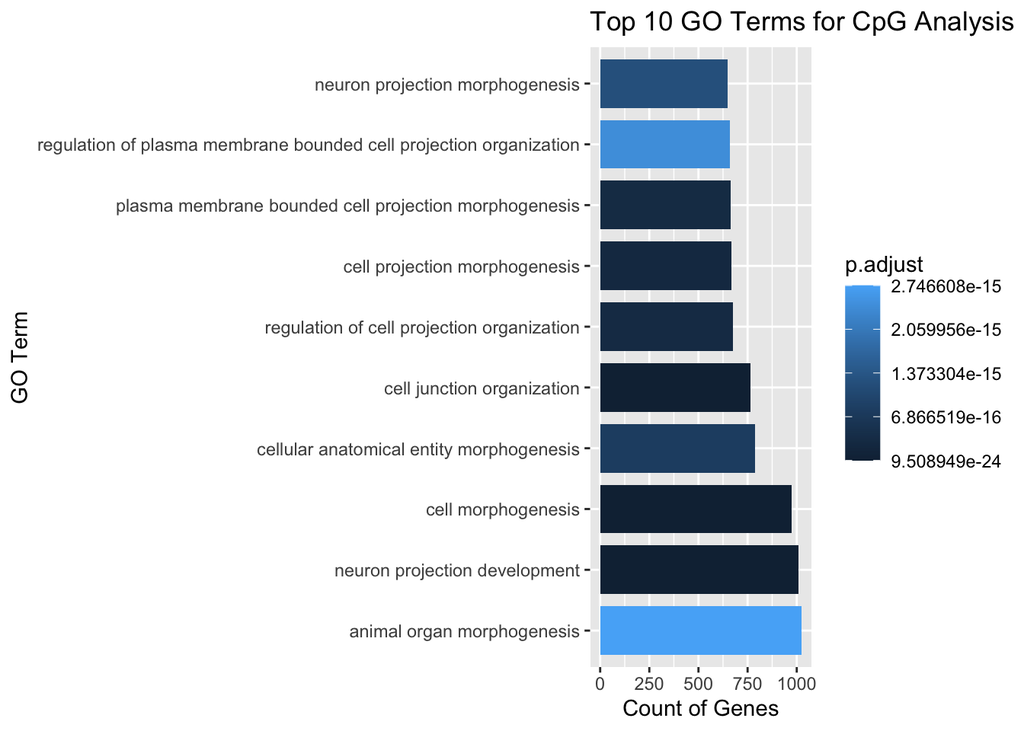

```r
# Sort the GO results by the number of genes (N)
topGOcpg_sorted <- topGOcpg[order(topGOcpg$N), ]

# Create a bar plot for the top 10 GO terms
ggplot(topGOcpg_sorted[1:10, ], aes(x = reorder(Term, -N), y = N, fill = FDR.DE)) +
  geom_bar(stat = "identity", width = 0.8) +  # Create bars with adjusted width
  coord_flip() +  # Flip coordinates for better readability of GO terms
  labs(title = "Top 10 GO Terms for CpG Analysis",  # Title of the plot
       x = "GO Term",                             # Label for x-axis
       y = "Count of Genes",                      # Label for y-axis
       fill = "p.adjust"
  )
```

## 12. Writing data for comparison of results

```r
write.table(EntrezIDs, sep= "\t", file="EntrezIDs_CpG_results.txt")
write.table(EntrezIDs_bmp, sep= "\t", file="EntrezIDs_bmp_results.txt")
CpG_GSA_res <- topGO(goanaOut, ontology="BP", number=100)
bmp_GSA_res <- topGO(goanaOut_bmp, ontology="BP", number=100)
write.table(CpG_GSA_res, sep= "\t", file="CpG_GSA_results.txt")
write.table(bmp_GSA_res, sep= "\t", file="bmp_GSA_results.txt")
```